# Stroop Effect

Enrique Araujo

July 2018

### The Stroop test

In the Stroop test, participants are given a list of words, where each is filled with a color. The task is to say out loud the color of the word. This task in done in two conditions: congruent or incongruent. In the first one, the words are colors, and are printed in the matching color. In the second one, the word says one color, but it’s printed in another. In both cases, we measure the time it takes to name all the colors. Each participant records a time for each condition. In this exercise, the type of test is the independent variable, congruent or incongruent. The dependent variable is the time it takes to name all the colors.

### The experimental data and hypothesis

```r
mydata = read.csv("stroopdata.csv")
structure(mydata)
```

```
##    Congruent Incongruent
## 1     12.079      19.278
## 2     16.791      18.741
## 3      9.564      21.214
## 4      8.630      15.687
## 5     14.669      22.803
## 6     12.238      20.878
## 7     14.692      24.572
## 8      8.987      17.394
## 9      9.401      20.762
## 10    14.480      26.282
## 11    22.328      24.524
## 12    15.298      18.644
## 13    15.073      17.510
## 14    16.929      20.330
## 15    18.200      35.255
## 16    12.130      22.158
## 17    18.495      25.139
## 18    10.639      20.429
## 19    11.344      17.425
## 20    12.369      34.288
## 21    12.944      23.894
## 22    14.233      17.960
## 23    19.710      22.058
## 24    16.004      21.157
```

The data I’m using for this analysis contains results for 24 participants over the two tasks, with the times measured in seconds. As each participant does each task, I have *paired samples* and I’ll be looking at the *pairwise difference* in order to draw conclusions.

Let $\mu_{C}$ be the population mean for the congruent test, and $\mu_{I}$ for the incongruent. Their difference $\mu_{d} = \mu_{C} - \mu_{I}$ is the difference between the population means.

Therefore, the null hypothesis $H_0$ is that the test subjects score the same time on both tests, which means that the difference between the average completion times for each condition $\mu_{d}$ is zero:

$$H_0: \mu_{d} = 0$$

Thus, the alternate hypothesis $H_1$ is that the type of test does affect the outcome and the times will be different, such that the difference between the means is not zero. The times can be better, or worse:

$$H_1: \mu_{d} \neq 0$$

### Establishing the test

The nature of the experiment and data recollection means that the most suitable test is a **paired samples t-test**:

- Participants go through each test in the same order: first congruent, then incongruent. Times are recorded and are dependent.
- We have 24 samples (low amount) for a population for which we don’t know parameters like the mean or standard deviation, and thus we will have to approximate them.
- We assume that the populations are normally distributed.
- Paired test means the variance of the two populations can be different and won’t introduce errors in the test.

The test will be *two-sided*, as it’s possible that a participant scores a lower time in the second test. The paired t-test will help determine if the conditions have a positive or negative effect on performance.

### Descriptive statistics

Before executing the test, however, first I’ll take a look at some statistics of our data. I’ll draw a summary, which includes the quantiles, median and mean, and then calculate the standard deviation. First, the congruent task:

```r
summary(mydata$Congruent)
```

```
##    Min. 1st Qu.  Median    Mean 3rd Qu.    Max.
##    8.63   11.90   14.36   14.05   16.20   22.33
```

```r
sd (mydata$Congruent)
```

```
## [1] 3.559358
```

In this first task, the average completion time is 14.05 seconds, with a SD of 3.559 seconds. The fastest participant completed the test more that twice as fast as the slowest one (8.63s vs 22.33s).

Now, I’ll compute the same statistics for the incongruent task:

```r
summary(mydata$Incongruent)
```

```
##    Min. 1st Qu.  Median    Mean 3rd Qu.    Max.
##   15.69   18.72   21.02   22.02   24.05   35.26
```

```r
sd(mydata$Incongruent)
```

```
## [1] 4.797057
```

### Distribution of sample data

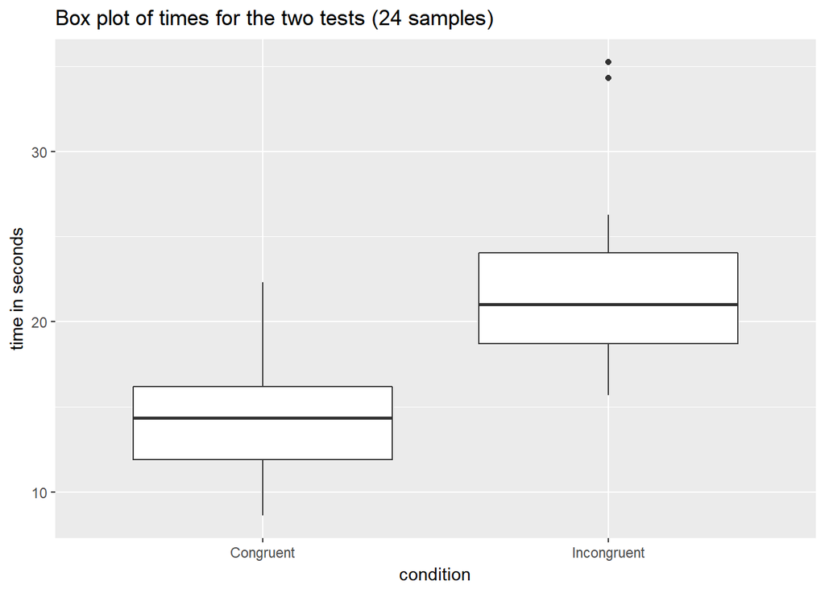

This is a boxplot split by the testing condition. Here it’s possible to see the clear difference in the completion time for each. Data is also quite normally distributed, and the variance is also similar for both cases. However, there are some possible outliers in the data for the incongruent task.

### Executing the t-test

Finally, I calculate the t-test using R’s *t.test* function. As mention before, it’s a two-sided paired test. I chose a 99% confidence interval based on the statistics I calculated before:

```r
t.test(mydata$Congruent, mydata$Incongruent,
       alternative = "two.sided",
       paired=TRUE,
       conf.level = 0.99)
```

```
##
##  Paired t-test
##
## data:  mydata$Congruent and mydata$Incongruent
## t = -8.0207, df = 23, p-value = 4.103e-08
## alternative hypothesis: true difference in means is not equal to 0
## 99 percent confidence interval:
##  -10.752556  -5.177027
## sample estimates:
## mean of the differences
##               -7.964792
```

The results are clear. With a t-score of -8.0207 and a minuscule p-value, we reject the null hypothesis. The differing test conditions had a definite effect on the participants performance. Subjects did noticeably worse with the incongruent colors, taking more time to name them, compared to the congruent task.

### Closing remarks

The results observed show that people have more trouble naming colors when they read a word with a different color in it. This phenomenon is known as interference and happens because the brain is used to reading words, like it’s automatic. So, when it’s presented with a task that demands more effort, like naming the color, it still does the reading and slows down our responses (Farnsworth, 2017).

Were the words in an unknown language, it’s possible the participants wouldn’t be negatively affected. However, it might be interesting to perform the test on bilingual candidates.

As this test can rate an individual’s cognitive performance by using interference, I can think of some other experiments that involve two distinct activities. For example, a person can be told to catch colored balls and say the color out loud while doing it. In this case, the naming could be a distraction and might make the person drop some balls, or maybe the opposite can happen, and they focus on the catching and stop naming. I think that any situation that pits an ordinary, almost automatic task, with one that is a bit more demanding, can produce effects like Stroop’s.

#### References

Farnsworth, B., Ph.D. (2017, August 23). The Stroop Effect - How it Works and Why. Retrieved from https://imotions.com/blog/the-stroop-effect/